# Homework 4

Andrew Maloney

3/1/2019

## Loading packages and data set

```r
library(dplyr)
```

```r
library(forcats)
library(ggplot2)
library(ggmosaic)

ChickWeight <- ChickWeight
glimpse(ChickWeight)  #Exploring
```

```
## Observations: 578
## Variables: 4
## $ weight <dbl> 42, 51, 59, 64, 76, 93, 106, 125, 149, 171, 199, 205, 40,…
## $ Time   <dbl> 0, 2, 4, 6, 8, 10, 12, 14, 16, 18, 20, 21, 0, 2, 4, 6, 8,…
## $ Chick  <ord> 1, 1, 1, 1, 1, 1, 1, 1, 1, 1, 1, 1, 2, 2, 2, 2, 2, 2, 2, …
## $ Diet   <fct> 1, 1, 1, 1, 1, 1, 1, 1, 1, 1, 1, 1, 1, 1, 1, 1, 1, 1, 1, …
```

```r
summary(ChickWeight)  #Exploring
```

```
##      weight           Time           Chick     Diet
##  Min.   : 35.0   Min.   : 0.00   13     : 12   1:220
##  1st Qu.: 63.0   1st Qu.: 4.00   9      : 12   2:120
##  Median :103.0   Median :10.00   20     : 12   3:120
##  Mean   :121.8   Mean   :10.72   10     : 12   4:118
##  3rd Qu.:163.8   3rd Qu.:16.00   17     : 12
##  Max.   :373.0   Max.   :21.00   19     : 12
##                                  (Other):506
```

# 1.

```r
weight0 <- ChickWeight %>% group_by(Diet) %>% summarize(nChicks = n(), avgWeight = mean(weight, na.rm = TRUE), sd_weight = sd(weight, na.rm = TRUE))
print(weight0)
```

```
## # A tibble: 4 x 4
##   Diet  nChicks avgWeight sd_weight
##   <fct>   <int>     <dbl>     <dbl>
## 1 1         220      103.      56.7
## 2 2         120      123.      71.6
## 3 3         120      143.      86.5
## 4 4         118      135.      68.8
```

# 2.

##### Data for all chicks with complete information.

```r
tabulate(ChickWeight$Chick) # There are 5 chicks with counts < 12. Remove
```

```
##  [1]  2  7  8 12 12 12 12 11 12 12 12 12 12 12 12 12 12 12 12 12 12 12 12
## [24] 12 12 12 12 12 12 12 12 12 12 12 12 12 12 12 12 12 10 12 12 12 12 12
## [47] 12 12 12 12
```

```r
ChickWeight %>% group_by(Chick) %>% summarize(n = n())#Chicks 18, 16, 15, 8, and 44 all have less than 12 measurements
```

```
## # A tibble: 50 x 2
##    Chick     n
##    <ord> <int>
##  1 18        2
##  2 16        7
##  3 15        8
##  4 13       12
##  5 9        12
##  6 20       12
##  7 10       12
##  8 8        11
##  9 17       12
## 10 19       12
## # … with 40 more rows
```

```r
complete <- ChickWeight %>% group_by(Chick) %>% mutate(n = n()) %>% filter(n() == 12)
print(head(complete, 3))
```

```
## # A tibble: 3 x 5
## # Groups:   Chick [1]
##   weight  Time Chick Diet      n
##    <dbl> <dbl> <ord> <fct> <int>
## 1     42     0 1     1        12
## 2     51     2 1     1        12
## 3     59     4 1     1        12
```

# 3.

##### Introduce a new variable that measures the current weight difference compared to day 0.

```r
complete <- complete %>% group_by(Chick) %>% mutate(weightgain = weight[Time == Time] - weight[Time == 0])
complete
```

```
## # A tibble: 540 x 6
## # Groups:   Chick [45]
##    weight  Time Chick Diet      n weightgain
##     <dbl> <dbl> <ord> <fct> <int>      <dbl>
##  1     42     0 1     1        12          0
##  2     51     2 1     1        12          9
##  3     59     4 1     1        12         17
##  4     64     6 1     1        12         22
##  5     76     8 1     1        12         34
##  6     93    10 1     1        12         51
##  7    106    12 1     1        12         64
##  8    125    14 1     1        12         83
##  9    149    16 1     1        12        107
## 10    171    18 1     1        12        129
## # … with 530 more rows
```

```r
print(head(complete, 3))
```

```
## # A tibble: 3 x 6
## # Groups:   Chick [1]
##   weight  Time Chick Diet      n weightgain
##    <dbl> <dbl> <ord> <fct> <int>      <dbl>
## 1     42     0 1     1        12          0
## 2     51     2 1     1        12          9
## 3     59     4 1     1        12         17
```

# 4.

##### Use {ggplot2} to create side-by-side boxplots of weightgain by Diet for day 21.

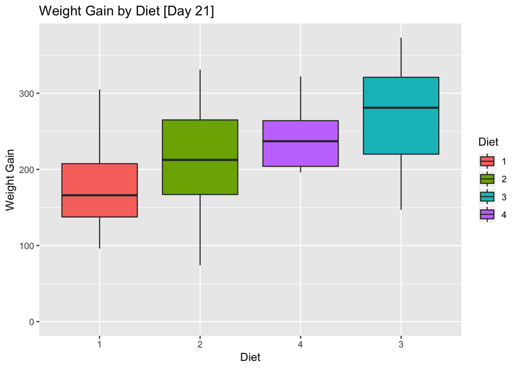

```r
complete_21 <- complete %>% mutate(weightgain = weight[Time ==21])

complete_21 %>% ggplot(aes(x = reorder(Diet, weightgain, FUN = median), y = weightgain))+
  geom_boxplot(aes(fill = Diet)) + expand_limits(y = 0)+
   ggtitle("Weight Gain by Diet [Day 21]") + xlab("Diet") + ylab("Weight Gain")
```

**Additional observations:** It seems that diet number 2 has the largest whiskers and diet number 4 has the lowest amount of observations. The boxplots are all of uneven size.

# 5.

##### Which chick gained the most weight and which gained the least weight? What diets were they on?

```r
complete %>% mutate(weightgain = sum(weightgain)) %>% distinct(weightgain) %>% arrange(weightgain)
```

```
## # A tibble: 45 x 2
## # Groups:   Chick [45]
##    weightgain Chick
##         <dbl> <ord>
##  1        291 24
##  2        322 13
##  3        449 20
##  4        470 9
##  5        505 10
##  6        525 19
##  7        606 17
##  8        688 4
##  9        738 30
## 10        738 37
## # … with 35 more rows
```

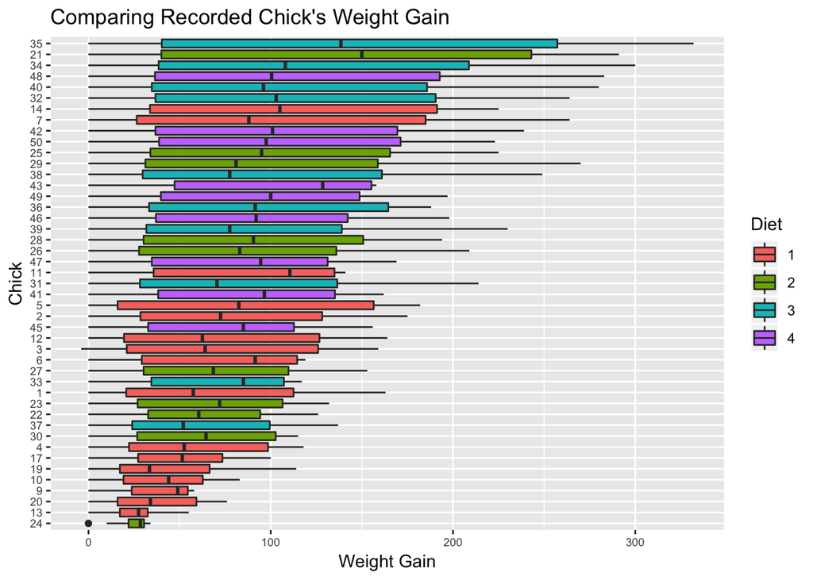

```r
complete %>% ggplot(aes(x = reorder(Chick, weightgain), y = weightgain, fill = Diet))+
  geom_boxplot() + coord_flip()+
  ggtitle("Comparing Recorded Chick's Weight Gain") + xlab("Chick") + ylab("Weight Gain") + theme(axis.text=element_text(size=7))
```

###### Chick 35 gained the most weight and was on diet 3. Chick 24 gained the least weight and was on diet 2,

# 6.

##### For the chicks with the least and the most weight at time 0, plot their growth trajectories over time.

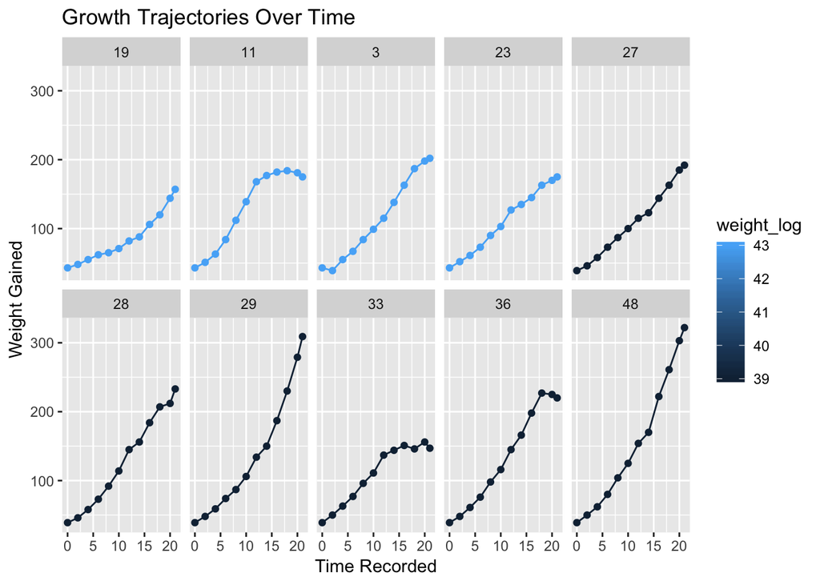

```r
Series <- complete %>% group_by(Chick) %>% mutate(weight_log = weight[Time == 0]) %>% filter(weight_log == 39 | weight_log == 43) %>% arrange(weight_log) #Smallest weight at time 0 and Largest weight at time 0
#print(Series)

Series %>% ggplot(aes(x = Time, y = weight, color = weight_log))+
  geom_line() + geom_point() + facet_wrap(~Chick, nrow = 2)+
  ggtitle("Growth Trajectories Over Time") + xlab("Time Recorded") + ylab("Weight Gained")
```

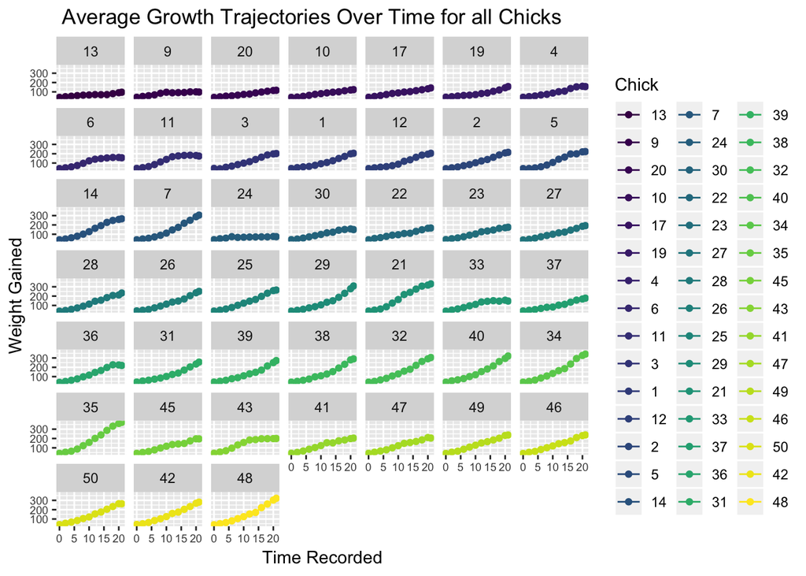

```r
completeAvg <- complete %>% group_by(Chick) %>% mutate(weight_log_avg = mean(weight[Time])) # Mean weight for all chicks
#print(completeAvg)

completeAvg %>% ggplot(aes(x = Time, y = weight, color = Chick))+
  geom_line() + geom_point() + facet_wrap(~Chick) + theme(axis.text=element_text(size=7))+
  ggtitle(" Average Growth Trajectories Over Time for all Chicks") + xlab("Time Recorded") + ylab("Weight Gained")
```

###### Using ggplot, I have plotted the growth trajectories for chicks with most and least weight at time 0. I have also plotted the trajectories for all chicks(calculated as the mean weight for each chick at each time). I found some interesting results. When comparing the growth trajectories of (Most and Least at time 0) vs (all chicks and mean weight) it seemed that the growth tracjetories were very similar. I did notice that the trajectories for (all chicks and mean weight) was more linear. I believe this is due to the larger amount of observations plotted.

# 7.

##### What else do you find interesting in the dataset?

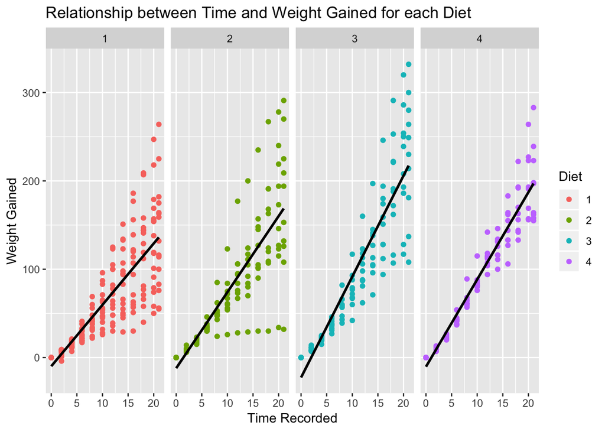

```r
complete %>% ggplot(aes(x = Time, y = weightgain, color = Diet))+
  geom_point()+ geom_smooth(method = "lm", se = FALSE, color = 'black') + facet_grid(cols = vars(Diet)) +
  ggtitle("Relationship between Time and Weight Gained for each Diet") + xlab("Time Recorded") + ylab("Weight Gained") # Using se = FALSE was found here: http://www.sthda.com/english/wiki/print.php?id=188
```

###### Using the complete data.frame, I wanted to see the relationship between time and weight gain for each diet. Looking at the scatter plots from ggplot, we can see that diet number 4 points are tightly clusted together. I believe for the relationship between time and weight gain, diet number 4 has the highest correlation. Also, I beleive diet number 1 has the lowest correlation. There seems to be a moderately strong - strong, positive, linear relationship between time and weight gain for each diet.